## Subject :- M508 Big Data Analytics Individual Project

## Name :- Harjot Singh

## Student ID :- GH1048197

# Automated IT Service Ticket Classification Using NLP and Machine Learning

## 1. Problem Statement

Employees and internal users submit a high number of IT service tickets to modern organisations. They might be hardware, access, storage, purchase, HR, internal project or admin related tickets. Many businesses have to deal with manually reviewing and ticketing the ticket to the appropriate team. This manual handling process can be time consuming and lead to delays if tickets are forwarded to the wrong department.

The IT Service Ticket classification challenge tackled in this project is the manual and slow classification of IT service tickets. Properly classified tickets unlock the time management that will not only shorten the resolution process but will cause support teams to dedicate additional time to reassigning tickets and users to waiting for support. This can impact employee effectiveness and impact the quality of IT service management in general.

This project re-formulates the problem to NLP problem. The system will take the text content of each ticket in the Document column and try to guess which ticket category (from the Topic_group column) the ticket belongs to. The goal is to develop an automatic ticket classification system that can help route tickets faster, minimize manual effort and enhance the service desk.

## 2. Project Objectives

The goal of this project is as follows: To create and deploy an end-to-end NLP pipeline for automatic IT service ticket classification. The system will analyze the text in the tickets and guess the appropriate topic group for each ticket.

The aims are:

To load and view the IT Service Ticket Classification data set.

To learn the structure of the dataset, including the Document and Topic_group columns.

To preprocess and clean the text of the ticket for NLP modelling.

To investigate distribution of ticket types and look for any potential class imbalance.

To encode text in tickets into numerical features with the help of text vectorisation methods.

To train the machine learning models for classifying tickets in multiple classes.

To evaluate model performance using suitable classification metrics such as accuracy, precision, recall, F1-score, and confusion matrix.

To compare the performance of different models and find out about the best model.

To provide an understanding of the strengths and weaknesses of the proposed NLP pipeline.

To supply suggestions on how the model could be utilized in an IT service desk environment.

## 3. Business Importance

Employees rely on IT systems, devices, software, accounts, and access rights to carry out a daily business they are dependent on IT service desks to complete. An IT ticket has to be delivered to the appropriate support team promptly. Assigning the ticket to the incorrect team could require the ticket to be reassigned, extending resolution time and further delaying employee support.

It can be challenging to classify tickets manually if there are a large number of them. For the support agents, they have to read each ticket to see what the problem is, and determine what category each ticket belongs to. This can take time, be variable, and rely on the discretion and professional judgment of individuals. By using automated NLP-based ticket classification system, this workload can be cut by anticipating the right group of topics from the text of ticket.

This is a good problem to solve for the company, for a number of reasons. It can enhance the speed of ticket routing, minimize the need for manual verification, enable quicker reply times, and assist agents to concentrate on resolving the issue, not the claim. The system could also have a positive effect on productivity in the service desk, directing tickets like hardware problems, access requests, purchase requests, storage requests, and administrative rights requests to the proper team early on.

The project facilitates improved IT service management from a business point of view. Being able to classify a ticket faster and more accurately will benefit employee satisfaction, minimise delays to business operations and enable the organisation to utilise its support resources more effectively.

## 4. Dataset Source

The dataset used in this project is the **IT Service Ticket Classification Dataset**, collected from Kaggle.

Dataset URL:  
https://www.kaggle.com/datasets/adisongoh/it-service-ticket-classification-dataset

Dataset file path in Kaggle Notebook:  
`/kaggle/input/datasets/adisongoh/it-service-ticket-classification-dataset/all_tickets_processed_improved_v3.csv`

The dataset contains **47,837 rows** and **2 columns**. Each row represents one IT service ticket. The dataset is suitable for this project because it contains textual ticket content and a corresponding category label, which allows the business problem to be formulated as a supervised NLP classification task.

The dataset was selected as an external public dataset and was not used in the module exercises.

## 5. Dataset Description

The IT Service Ticket Classification Dataset consists of textual data from IT support tickets. Each line of the data includes a single ticket from a user or employee who requested IT support. Total records in the dataset: 47837 records, Number of Records per column: 2, which are suitable for supervised NLP classification model.

The first column is Document containing the text/content of the support ticket. This column is the column that will get input to the NLP pipeline as the model will take this text to understand what the user has reported. This text can contain hardware-related, system access, storage, purchase request, HR support, or administrative rights problems or internal projects related to.

The second column is Topic_group which refers to the category used for each ticket. This column will be targeted as the class to be predicted based on the text of the tickets. These options are divided into categories such as: Hardware, HR Support, Access, Miscellaneous, Storage, Purchase, Internal Project, and Administrative rights.

This type of data is appropriate for the project due to its clearly defined, structured input and output. The Document column is used for unstructured text data, the Topic_group column is used for labelled categories. This enables the business problem to be treated as a multi-class text classification problem, as the system needs to classify each IT ticket into the appropriate support topic group.

## 6. NLP Task Formulation

The problem is approached as a multi-class text classification problem in NLP. The text in the ticket (Document column) is the input, while the category of the ticket (Topic_group column) is the output.

The NLP system's aim is to automatically extract the text from an IT service ticket, and classify the appropriate topic group. Several types of tickets can be created per "category", for example Hardware, HR Support, Access, Miscellaneous, Storage, Purchase, Internal Project, Administrative rights.

The raw text of the ticket will be cleaned and preprocessed in this task. The text will be preprocessed and then mapped, or transformed, to numerical features through text vectorisation. These numerical features will then be placed in machine learning models to be trained. The trained model will learn from the tickets' text and then classify newly received tickets into an appropriate topic group.

This task is crucial as it can assist the IT service desk in redirecting tickets to the appropriate support team more efficiently. It can help minimize manual sorting, lessen reassignment time delays and improve the overall ticket resolution experience.

## 7. High-Level System Design

The NLP system that is proposed here is an end-to-end pipeline that automatically classifies IT service tickets. The system begins with the IT service ticket dataset and populated Text column with the text included with the ticket and the Topic_group column with the category of the ticket. The text of the ticket is first checked to see how it's structured, how good it is, missing values, duplicate tickets, and the distribution of categories.

The data in the text is then cleaned and preprocessed after undergoing the data inspection process. At this stage, all irrelevant symbols, special characters, extra spaces and punctuation are eliminated. The text is also formatted into a more standard text to better enable the machine learning models to process it. This is a crucial step because the raw text data is unstructured and cannot be used directly by machine learning algorithms.

Text vectorisation is then used to convert the cleaned text to numeric features. TF-IDF vectorisation is used in this project since it emphasizes meaningful words and suppresses the impact of common words. These numerical features will be used as input for machine learning models.

The high-level flow of the system is:

Dataset Loading → Data Inspection → Text Cleaning → Text Preprocessing → TF-IDF Vectorisation → Model Training → Model Evaluation → Model Comparison → Business Recommendation

[figure not shown]

```python
# High-Level NLP Pipeline for IT Service Ticket Classification
```

```python
# Basic data handling
import pandas as pd
import numpy as np

# Text cleaning
import re
import string

# Data visualisation
import matplotlib.pyplot as plt

# NLP preprocessing
import nltk
from nltk.corpus import stopwords
from nltk.stem import WordNetLemmatizer

# Machine learning preparation
from sklearn.model_selection import train_test_split
from sklearn.preprocessing import LabelEncoder

# Text vectorisation
from sklearn.feature_extraction.text import TfidfVectorizer

# Machine learning models
from sklearn.naive_bayes import MultinomialNB
from sklearn.linear_model import LogisticRegression
from sklearn.svm import LinearSVC

# Evaluation metrics
from sklearn.metrics import (
    accuracy_score,
    precision_score,
    recall_score,
    f1_score,
    classification_report,
    confusion_matrix
)

# Model saving
import joblib

# Ignore warnings
import warnings
warnings.filterwarnings("ignore")
```

```python
# Download required NLTK resources
nltk.download('stopwords')
nltk.download('wordnet')
nltk.download('omw-1.4')
```

```
True
```

```python
# Dataset file path
file_path = "/kaggle/input/datasets/adisongoh/it-service-ticket-classification-dataset/all_tickets_processed_improved_v3.csv"

# Load dataset
df = pd.read_csv(file_path)

# Display first 5 rows
print("First 5 rows:")
display(df.head())

# Display last 5 rows
print("Last 5 rows:")
display(df.tail())

# Check dataset shape
print("Dataset shape:")
print(df.shape)

# Check column names
print("Column names:")
print(df.columns.tolist())
```

```
First 5 rows:
```

|  | Document | Topic_group |
| --- | --- | --- |
| 0 | connection with icon icon dear please setup ic... | Hardware |
| 1 | work experience user work experience user hi w... | Access |
| 2 | requesting for meeting requesting meeting hi p... | Hardware |
| 3 | reset passwords for external accounts re expir... | Access |
| 4 | mail verification warning hi has got attached ... | Miscellaneous |

```
Last 5 rows:
```

|  | Document | Topic_group |
| --- | --- | --- |
| 47832 | git space for a project issues with adding use... | Access |
| 47833 | error sent july error hi guys can you help out... | Miscellaneous |
| 47834 | connection issues sent tuesday july connection... | Hardware |
| 47835 | error cube reports sent tuesday july error hel... | HR Support |
| 47836 | running out on extensions hello please be advi... | Hardware |

```
Dataset shape:
(47837, 2)
Column names:
['Document', 'Topic_group']
```

## 8. Dataset Loading

The IT Service Ticket Classification Dataset was successfully loaded from the input directory on Kaggle. All_tickets_processed_improved_v3.csv is the dataset file to use in this notebook.

To ensure that the data was loaded properly, the first five and last five records were shown. The output shows that there are two columns in the data set: Document and Topic_group. The text for each one of the IT Service tickets is in the Document column and the Topic_group column lists the topic assigned to each IT service ticket.

The shape of the data set is (47837, 2). The data in each row is one IT service ticket record. This verifies that the data set has been loaded properly, and can now be examined, cleaned, preprocessed, and modelled.

```python
print("Dataset information:")
df.info()

print("\nData types:")
print(df.dtypes)

print("\nNumber of rows and columns:")
print("Rows:", df.shape[0])
print("Columns:", df.shape[1])

print("\nColumn names:")
print(df.columns.tolist())

print("\nBasic dataset summary:")
display(df.describe(include="all"))

print("\nMemory usage:")
print(df.memory_usage(deep=True))
```

```
Dataset information:
<class 'pandas.core.frame.DataFrame'>
RangeIndex: 47837 entries, 0 to 47836
Data columns (total 2 columns):
 #   Column       Non-Null Count  Dtype
---  ------       --------------  -----
 0   Document     47837 non-null  object
 1   Topic_group  47837 non-null  object
dtypes: object(2)
memory usage: 747.6+ KB

Data types:
Document       object
Topic_group    object
dtype: object

Number of rows and columns:
Rows: 47837
Columns: 2

Column names:
['Document', 'Topic_group']

Basic dataset summary:
```

|  | Document | Topic_group |
| --- | --- | --- |
| count | 47837 | 47837 |
| unique | 47837 | 8 |
| top | connection with icon icon dear please setup ic... | Hardware |
| freq | 1 | 13617 |

```
Memory usage:
Index               132
Document       16306737
Topic_group     2806644
dtype: int64
```

## 9. Dataset Structure Inspection

Data structure of the dataset was checked to gain insights into its number of records, columns, data types, and memory usage. The output indicates that there are 47,837 rows of data and 2 columns in the data set: Document and Topic_group.

Both columns have the object data type. This is as expected; the Document column is for the text content of the ticket, and the Topic_group column is for the text labels in the categories. Here we can also see that both the columns contain 47,837 non-null values, so there is no missing value until now.

The Document output value has 47,837 distinct values in the summary output. This implies that all the texts of the tickets are different in the dataset. The number of unique values for the Topic_group column is 8. The top category is Hardware with 13,617 records. This means that hardware is the most prevalent type of ticket from all of the data other than these.

As seen in memory usage it can be seen that the memory used by Document column is the most because the long text values are stored in that column. It's a common property of the NLP datasets. The overall structure of the dataset is clean and well organized for subsequent data quality evaluation, text pre-processing and training the model.

```python
print("Missing values in each column:")
print(df.isnull().sum())

print("\nMissing value percentage:")
missing_percentage = (df.isnull().sum() / len(df)) * 100
print(missing_percentage)

print("\nTotal missing values in dataset:")
print(df.isnull().sum().sum())

print("\nRows with missing values:")
display(df[df.isnull().any(axis=1)])
```

```
Missing values in each column:
Document       0
Topic_group    0
dtype: int64

Missing value percentage:
Document       0.0
Topic_group    0.0
dtype: float64

Total missing values in dataset:
0

Rows with missing values:
```

|  | Document | Topic_group |
| --- | --- | --- |

## 10. Missing Value Check

Both columns of the dataset, Document and Topic_group, were checked for any missing values. As you can see in the output, there's no value that's missing in either column. There are no missing values on the Document column, and no missing values on the Topic_group column.

The percentage of missing values for both columns is 0.0% and the overall number of missing values in the data is 0. This is because all records contain a text and the associated category label is defined.

Since there are no missing values, no rows need to be removed or imputed at this stage. The data set is ready for the next data quality check, which in this case is for duplicate records.

```python
print("Total duplicate rows:")
print(df.duplicated().sum())

print("\nDuplicate percentage:")
duplicate_percentage = (df.duplicated().sum() / len(df)) * 100
print(round(duplicate_percentage, 2), "%")

print("\nDuplicate rows:")
display(df[df.duplicated()])
```

```
Total duplicate rows:
0

Duplicate percentage:
0.0 %

Duplicate rows:
```

|  | Document | Topic_group |
| --- | --- | --- |

## 11. Duplicate Record Check

Data was checked for any duplicate records to avoid having repeated entries impacting the modeling process. Duplicate records may lead to bias, as duplicated tickets can give an inflated sense of how well the model is performing, and may lead to the same ticket showing up multiple times.

The output indicates that there are no 0 duplicate rows in the dataset. The duplicate percentage is 0.0%, indicating that there are no duplicate records in the dataset.

No duplicate records at this point – no rows can be deleted. The data set is still 47,837 long and now ready for category analysis.

```python
print("Unique ticket categories:")
print(df["Topic_group"].unique())

print("\nTotal number of unique categories:")
print(df["Topic_group"].nunique())

print("\nCategory count:")
print(df["Topic_group"].value_counts())

print("\nCategory percentage:")
category_percentage = (df["Topic_group"].value_counts(normalize=True) * 100).round(2)
print(category_percentage)
```

```
Unique ticket categories:
['Hardware' 'Access' 'Miscellaneous' 'HR Support' 'Purchase'
 'Administrative rights' 'Storage' 'Internal Project']

Total number of unique categories:
8

Category count:
Topic_group
Hardware                 13617
HR Support               10915
Access                    7125
Miscellaneous             7060
Storage                   2777
Purchase                  2464
Internal Project          2119
Administrative rights     1760
Name: count, dtype: int64

Category percentage:
Topic_group
Hardware                 28.47
HR Support               22.82
Access                   14.89
Miscellaneous            14.76
Storage                   5.81
Purchase                  5.15
Internal Project          4.43
Administrative rights     3.68
Name: proportion, dtype: float64
```

```
Class distribution table:
```

| Topic_group | Ticket_Count | Percentage |
| --- | --- | --- |
| Hardware | 13617 | 28.47 |
| HR Support | 10915 | 22.82 |
| Access | 7125 | 14.89 |
| Miscellaneous | 7060 | 14.76 |
| Storage | 2777 | 5.81 |
| Purchase | 2464 | 5.15 |
| Internal Project | 2119 | 4.43 |
| Administrative rights | 1760 | 3.68 |

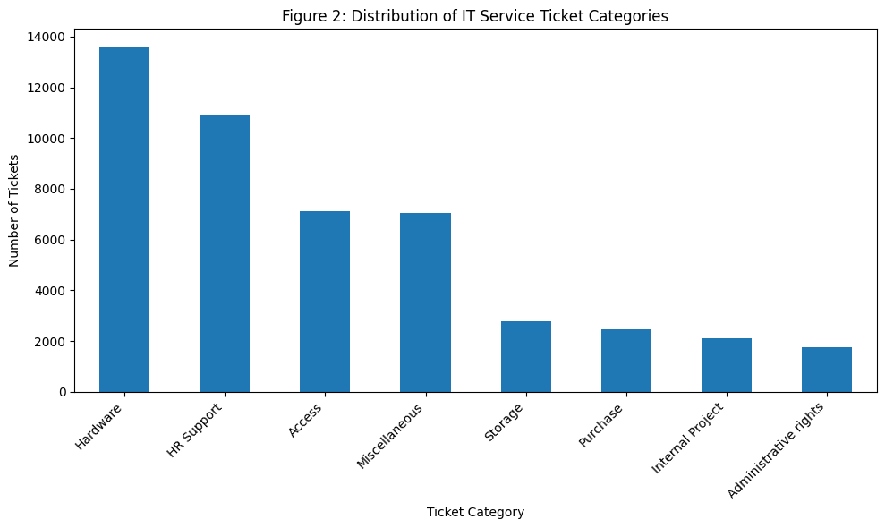

```python
# Count records in each category
class_counts = df["Topic_group"].value_counts()

# Calculate percentage of each category
class_percentages = (df["Topic_group"].value_counts(normalize=True) * 100).round(2)

# Create summary table
class_distribution = pd.DataFrame({
    "Ticket_Count": class_counts,
    "Percentage": class_percentages
})

print("Class distribution table:")
display(class_distribution)

# Plot class distribution
plt.figure(figsize=(10, 6))
class_counts.plot(kind="bar")

plt.title("Figure 2: Distribution of IT Service Ticket Categories")
plt.xlabel("Ticket Category")
plt.ylabel("Number of Tickets")
plt.xticks(rotation=45, ha="right")
plt.tight_layout()
plt.show()
```

## 12. Class Distribution Analysis

The number of tickets per class indicates that the data set is imbalanced, with the most tickets reported for the class called `Hardware` (13,617) followed by the class called `HR Support` (10,915). The smallest category is `Administrative rights` with 1,760 records.

This imbalancing has made model evaluation more than just accuracy becomes essential. Additionally, the precision, recall and F1 score will be employed to verify the performance of the model for all the categories.

```
Character length summary:
```

```
count    47837.000000
mean       291.881263
std        388.171200
min          7.000000
25%        110.000000
50%        175.000000
75%        304.000000
max       7015.000000
Name: char_length, dtype: float64
```

```
Word count summary:
```

```
count    47837.000000
mean        43.597341
std         56.736800
min          2.000000
25%         17.000000
50%         26.000000
75%         46.000000
max        981.000000
Name: word_count, dtype: float64
```

```
Average word count by category:
```

```
Topic_group
Hardware                 56.273041
Administrative rights    50.361932
Miscellaneous            42.953966
HR Support               37.766651
Internal Project         37.706937
Access                   35.600000
Purchase                 34.932630
Storage                  34.409795
Name: word_count, dtype: float64
```

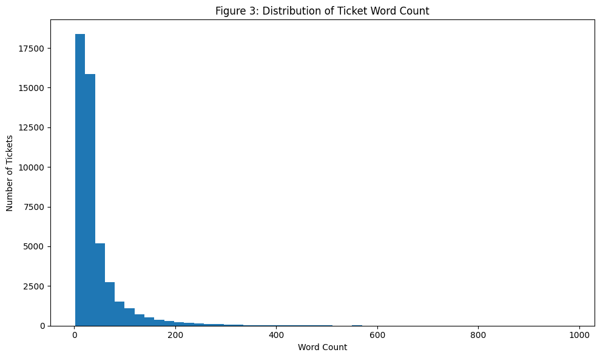

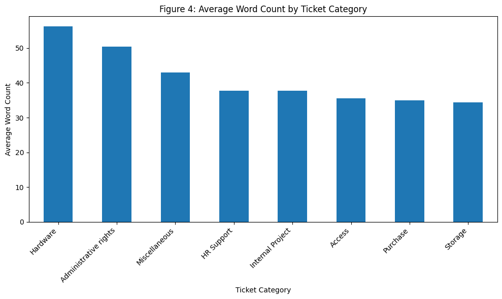

```python
# Create text length and word count columns
df["char_length"] = df["Document"].astype(str).apply(len)
df["word_count"] = df["Document"].astype(str).apply(lambda x: len(x.split()))

# Summary statistics
print("Character length summary:")
display(df["char_length"].describe())

print("\nWord count summary:")
display(df["word_count"].describe())

# Average word count by category
print("\nAverage word count by category:")
avg_word_count = df.groupby("Topic_group")["word_count"].mean().sort_values(ascending=False)
display(avg_word_count)

# Plot word count distribution
plt.figure(figsize=(10, 6))
plt.hist(df["word_count"], bins=50)

plt.title("Figure 3: Distribution of Ticket Word Count")
plt.xlabel("Word Count")
plt.ylabel("Number of Tickets")
plt.tight_layout()
plt.show()

# Plot average word count by category
plt.figure(figsize=(10, 6))
avg_word_count.plot(kind="bar")

plt.title("Figure 4: Average Word Count by Ticket Category")
plt.xlabel("Ticket Category")
plt.ylabel("Average Word Count")
plt.xticks(rotation=45, ha="right")
plt.tight_layout()
plt.show()
```

## 13. Text Length Analysis

The character length and word counts were analysed for the length of the ticket text. An average ticket is around 292 characters and 44 words long. Tickets tend to be short with a median of 26 words.

The maximum word count is 981, which shows that a few tickets are much longer. `Hardware` tickets have the highest average word count, while `Storage` tickets have the lowest average word count.

This analysis reveals that the length of the ticket is not uniformly distributed among the categories so this needs to be preprocessed before the model is built.

```python
print("Sample tickets from each category:")

sample_tickets = (
    df.groupby("Topic_group")
    .apply(lambda x: x[["Document", "Topic_group"]].sample(2, random_state=42))
    .reset_index(drop=True)
)

display(sample_tickets)
```

```
Sample tickets from each category:
```

|  | Document | Topic_group |
| --- | --- | --- |
| 0 | confluence access for wednesday february pm co... | Access |
| 1 | password reset open access dear can you please... | Access |
| 2 | set up and swap leased for new set up swap lea... | Administrative rights |
| 3 | windows upgrade failed upgrade failed hello pl... | Administrative rights |
| 4 | access to new pas friday february hi guys plea... | HR Support |
| 5 | new starter bucharest friday pm hello va date ... | HR Support |
| 6 | monitor request vulcan friday october pm hello... | Hardware |
| 7 | stopped when docker start was executed sent we... | Hardware |
| 8 | amend pm on wednesday pm hi please make code t... | Internal Project |
| 9 | create new unknown pipeline unknown pipeline s... | Internal Project |
| 10 | restart sent friday december restart hello can... | Miscellaneous |
| 11 | amend poll description for amend poll descript... | Miscellaneous |
| 12 | new delivery intend intend hello received inte... | Purchase |
| 13 | po thursday po hi please install cl thanks lea... | Purchase |
| 14 | mailbox problem july pm mailbox problem hello ... | Storage |
| 15 | new shared mailbox co wednesday november pm sh... | Storage |

## 14. Sample Ticket Analysis

Some of the sample tickets were presented from every category of the collection of `Topic_group`, to get an idea of the text patterns in the data set. Examples illustrate that there are various kinds of service requests in each category, including Access Requests, who can give admin rights, HR issues, Hardware Requests, Project Work, Purchase Requests, Storage Requests, and other tickets.

This step validates the meaningfulness of the `Document` column and the labels contained in the `Topic_group` column, which can be used for supervised NLP classification.

```python
# Create a copy of the original Document column for cleaning
df["clean_text"] = df["Document"].astype(str)

# Display original and new clean_text column
print("Original and clean text columns created:")
display(df[["Document", "clean_text", "Topic_group"]].head())

# Check updated dataset columns
print("\nUpdated column names:")
print(df.columns.tolist())

# Check updated dataset shape
print("\nUpdated dataset shape:")
print(df.shape)
```

```
Original and clean text columns created:
```

|  | Document | clean_text | Topic_group |
| --- | --- | --- | --- |
| 0 | connection with icon icon dear please setup ic... | connection with icon icon dear please setup ic... | Hardware |
| 1 | work experience user work experience user hi w... | work experience user work experience user hi w... | Access |
| 2 | requesting for meeting requesting meeting hi p... | requesting for meeting requesting meeting hi p... | Hardware |
| 3 | reset passwords for external accounts re expir... | reset passwords for external accounts re expir... | Access |
| 4 | mail verification warning hi has got attached ... | mail verification warning hi has got attached ... | Miscellaneous |

```
Updated column names:
['Document', 'Topic_group', 'char_length', 'word_count', 'clean_text']

Updated dataset shape:
(47837, 5)
```

## 15. Clean Text Column Creation

A new column called 'clean_text' is added to the ‘Document’ column. This helps not to alter the original text of the ticket and to clean and process the text separately.

```python
# Function to clean ticket text
def clean_ticket_text(text):
    text = str(text).lower()                      # Convert to lowercase
    text = re.sub(r"http\S+|www\S+", " ", text)   # Remove URLs
    text = re.sub(r"\S+@\S+", " ", text)          # Remove email addresses
    text = re.sub(r"[^a-zA-Z\s]", " ", text)      # Remove numbers, punctuation, and special characters
    text = re.sub(r"\s+", " ", text).strip()      # Remove extra spaces
    return text

# Apply cleaning function
df["clean_text"] = df["clean_text"].apply(clean_ticket_text)

# Display original and cleaned text
print("Original vs Cleaned Text:")
display(df[["Document", "clean_text", "Topic_group"]].head(10))

# Check clean_text length after cleaning
print("\nCleaned text sample:")
print(df["clean_text"].head())
```

```
Original vs Cleaned Text:
```

|  | Document | clean_text | Topic_group |
| --- | --- | --- | --- |
| 0 | connection with icon icon dear please setup ic... | connection with icon icon dear please setup ic... | Hardware |
| 1 | work experience user work experience user hi w... | work experience user work experience user hi w... | Access |
| 2 | requesting for meeting requesting meeting hi p... | requesting for meeting requesting meeting hi p... | Hardware |
| 3 | reset passwords for external accounts re expir... | reset passwords for external accounts re expir... | Access |
| 4 | mail verification warning hi has got attached ... | mail verification warning hi has got attached ... | Miscellaneous |
| 5 | mail please dear looks blacklisted receiving m... | mail please dear looks blacklisted receiving m... | Miscellaneous |
| 6 | prod servers tunneling prod tunneling va la tu... | prod servers tunneling prod tunneling va la tu... | Hardware |
| 7 | access request dear modules report report cost... | access request dear modules report report cost... | HR Support |
| 8 | reset passwords for our client and passwords c... | reset passwords for our client and passwords c... | Access |
| 9 | direct reports missing time please action repo... | direct reports missing time please action repo... | HR Support |

```
Cleaned text sample:
0    connection with icon icon dear please setup ic...
1    work experience user work experience user hi w...
2    requesting for meeting requesting meeting hi p...
3    reset passwords for external accounts re expir...
4    mail verification warning hi has got attached ...
Name: clean_text, dtype: object
```

## 16. Text Cleaning

The text on the ticket was cleaned up by converting to lower case and removing URLs, email addresses, numbers, punctuation, special characters and extra spaces.

The cleaned text was placed in the `clean_text` column. As seen in the output, the original `Document` column is unchanged and the `clean_text` column is suitable for use in NLP pre-processing.

This step minimizes noise in the text and arranges the data for tokenisation, removing of stop words and lemmatization.

```python
# Create stopword list and lemmatizer
stop_words = set(stopwords.words("english"))
lemmatizer = WordNetLemmatizer()

# Function for text preprocessing
def preprocess_text(text):
    words = str(text).split()  # Tokenisation

    words = [
        lemmatizer.lemmatize(word)
        for word in words
        if word not in stop_words and len(word) > 2
    ]

    return " ".join(words)

# Apply preprocessing
df["clean_text"] = df["clean_text"].apply(preprocess_text)

# Display preprocessed text
print("Preprocessed text sample:")
display(df[["Document", "clean_text", "Topic_group"]].head(10))

# Check if any clean_text values became empty
print("\nEmpty cleaned text records:")
print((df["clean_text"].str.strip() == "").sum())
```

```
Preprocessed text sample:
```

|  | Document | clean_text | Topic_group |
| --- | --- | --- | --- |
| 0 | connection with icon icon dear please setup ic... | connection icon icon dear please setup icon pe... | Hardware |
| 1 | work experience user work experience user hi w... | work experience user work experience user work... | Access |
| 2 | requesting for meeting requesting meeting hi p... | requesting meeting requesting meeting please h... | Hardware |
| 3 | reset passwords for external accounts re expir... | reset password external account expire day ask... | Access |
| 4 | mail verification warning hi has got attached ... | mail verification warning got attached please ... | Miscellaneous |
| 5 | mail please dear looks blacklisted receiving m... | mail please dear look blacklisted receiving ma... | Miscellaneous |
| 6 | prod servers tunneling prod tunneling va la tu... | prod server tunneling prod tunneling tunneling... | Hardware |
| 7 | access request dear modules report report cost... | access request dear module report report cost ... | HR Support |
| 8 | reset passwords for our client and passwords c... | reset password client password client dear ple... | Access |
| 9 | direct reports missing time please action repo... | direct report missing time please action repor... | HR Support |

```
Empty cleaned text records:
2
```

## 17. Text Preprocessing

The column, called `clean_text`, was preprocessed using text processing. The process consisted of tokenisation, removing stop words, removing short words and lemmatisation.

The output includes the output in the ticket text reduced to more meaningful terms. For instance, common words were deleted, and words were lemmatized, when it was possible.

Following pre-processing, the number of 2 records became zeros. These records will have to be removed before training the model as empty text will not give good features to classify.

```python
# Display original text, cleaned text, and category
comparison_df = df[["Document", "clean_text", "Topic_group"]].head(10)

print("Original vs Preprocessed Text:")
display(comparison_df)

# Show empty clean_text records
empty_text_records = df[df["clean_text"].str.strip() == ""]

print("\nEmpty clean_text records:")
display(empty_text_records[["Document", "clean_text", "Topic_group"]])

# Remove empty clean_text records
df = df[df["clean_text"].str.strip() != ""].reset_index(drop=True)

print("\nDataset shape after removing empty clean_text records:")
print(df.shape)

print("\nRemaining empty clean_text records:")
print((df["clean_text"].str.strip() == "").sum())
```

```
Original vs Preprocessed Text:
```

|  | Document | clean_text | Topic_group |
| --- | --- | --- | --- |
| 0 | connection with icon icon dear please setup ic... | connection icon icon dear please setup icon pe... | Hardware |
| 1 | work experience user work experience user hi w... | work experience user work experience user work... | Access |
| 2 | requesting for meeting requesting meeting hi p... | requesting meeting requesting meeting please h... | Hardware |
| 3 | reset passwords for external accounts re expir... | reset password external account expire day ask... | Access |
| 4 | mail verification warning hi has got attached ... | mail verification warning got attached please ... | Miscellaneous |
| 5 | mail please dear looks blacklisted receiving m... | mail please dear look blacklisted receiving ma... | Miscellaneous |
| 6 | prod servers tunneling prod tunneling va la tu... | prod server tunneling prod tunneling tunneling... | Hardware |
| 7 | access request dear modules report report cost... | access request dear module report report cost ... | HR Support |
| 8 | reset passwords for our client and passwords c... | reset password client password client dear ple... | Access |
| 9 | direct reports missing time please action repo... | direct report missing time please action repor... | HR Support |

```
Empty clean_text records:
```

|  | Document | clean_text | Topic_group |
| --- | --- | --- | --- |
| 10655 | for pm la la |  | Hardware |
| 35590 | for is down again for down again hi for down a... |  | Administrative rights |

```
Dataset shape after removing empty clean_text records:
(47835, 5)

Remaining empty clean_text records:
0
```

## 18. Original and Preprocessed Text Comparison

The preprocessed column called `clean_text' was used to compare with the original`Document' text. From the output it is observed that unnecessary words were eliminated from the text of the ticket and only meaningful words remained.

The number of records dropped to zero after preprocessing as only the words after stopword and short-word filtering were removed. The records have been deleted, since an empty text is not allowed for TF-IDF feature extraction or model training.

When the data is removed, there are 47,835 records and 5 columns. The `clean_text` table has no empty records.

```
Top 20 most common words:
```

|  | Word | Frequency |
| --- | --- | --- |
| 0 | please | 70212 |
| 1 | regard | 27286 |
| 2 | thank | 24962 |
| 3 | hello | 23025 |
| 4 | thanks | 19852 |
| 5 | sent | 14717 |
| 6 | issue | 14176 |
| 7 | access | 13309 |
| 8 | kind | 13252 |
| 9 | help | 11460 |
| 10 | tuesday | 10899 |
| 11 | wednesday | 10429 |
| 12 | dear | 10358 |
| 13 | error | 10152 |
| 14 | thursday | 9937 |
| 15 | change | 9793 |
| 16 | friday | 9447 |
| 17 | best | 9391 |
| 18 | july | 8790 |
| 19 | report | 8202 |

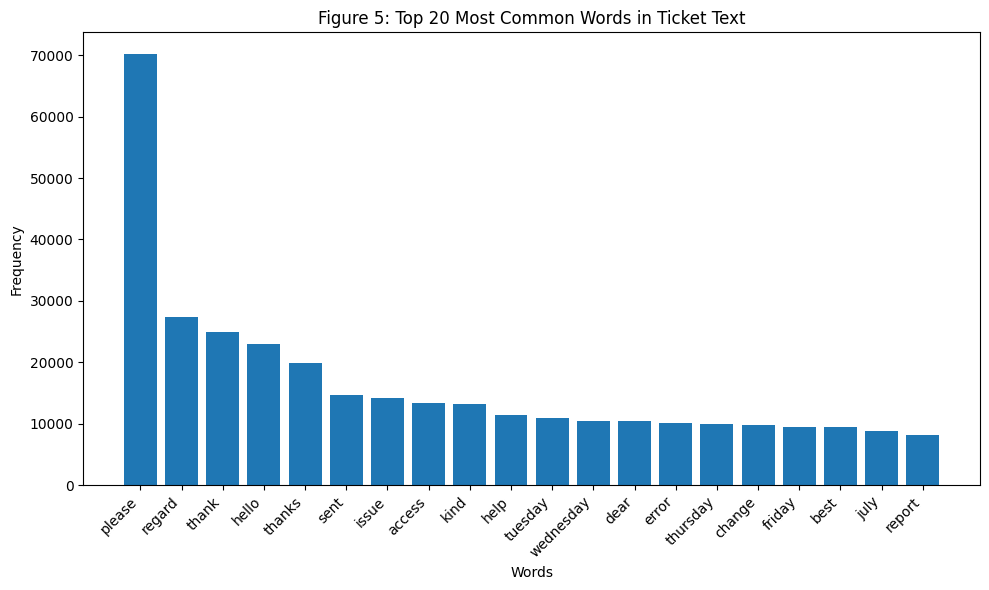

```
Average word count by category:
```

```
Topic_group
Hardware                 56.276880
Administrative rights    50.384309
Miscellaneous            42.953966
HR Support               37.766651
Internal Project         37.706937
Access                   35.600000
Purchase                 34.932630
Storage                  34.409795
Name: word_count, dtype: float64
```

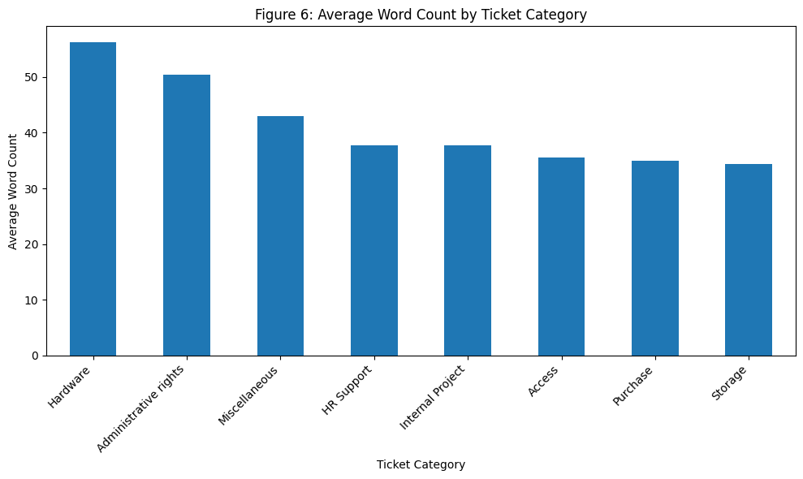

```
Top 10 words in each ticket category:

Category: Hardware
```

|  | Word | Frequency |
| --- | --- | --- |
| 0 | please | 19401 |
| 1 | regard | 9075 |
| 2 | hello | 7666 |
| 3 | thank | 7551 |
| 4 | issue | 6941 |
| 5 | sent | 6741 |
| 6 | thanks | 6067 |
| 7 | access | 4793 |
| 8 | help | 4121 |
| 9 | kind | 4085 |

```
Category: Access
```

|  | Word | Frequency |
| --- | --- | --- |
| 0 | please | 9006 |
| 1 | confluence | 4587 |
| 2 | user | 4201 |
| 3 | card | 3546 |
| 4 | regard | 3445 |
| 5 | hello | 3182 |
| 6 | thanks | 3150 |
| 7 | thank | 3097 |
| 8 | access | 2656 |
| 9 | password | 2386 |

```
Category: Miscellaneous
```

|  | Word | Frequency |
| --- | --- | --- |
| 0 | please | 11258 |
| 1 | change | 5217 |
| 2 | regard | 4129 |
| 3 | thank | 3866 |
| 4 | hello | 3405 |
| 5 | thanks | 3264 |
| 6 | add | 3200 |
| 7 | name | 2524 |
| 8 | sent | 2297 |
| 9 | approval | 2037 |

```
Category: HR Support
```

|  | Word | Frequency |
| --- | --- | --- |
| 0 | please | 16289 |
| 1 | thank | 6192 |
| 2 | leaver | 5865 |
| 3 | regard | 5399 |
| 4 | hello | 5383 |
| 5 | error | 5021 |
| 6 | form | 4886 |
| 7 | starter | 4494 |
| 8 | leave | 4215 |
| 9 | thanks | 3947 |

```
Category: Purchase
```

|  | Word | Frequency |
| --- | --- | --- |
| 0 | please | 4744 |
| 1 | purchase | 3798 |
| 2 | administrator | 2112 |
| 3 | item | 1955 |
| 4 | log | 1944 |
| 5 | order | 1839 |
| 6 | regard | 1825 |
| 7 | receive | 1660 |
| 8 | kind | 1654 |
| 9 | dear | 1640 |

```
Category: Administrative rights
```

|  | Word | Frequency |
| --- | --- | --- |
| 0 | upgrade | 2751 |
| 1 | please | 2383 |
| 2 | issue | 1486 |
| 3 | update | 1067 |
| 4 | regard | 1018 |
| 5 | hello | 972 |
| 6 | thank | 869 |
| 7 | sent | 832 |
| 8 | thanks | 559 |
| 9 | version | 555 |

```
Category: Storage
```

|  | Word | Frequency |
| --- | --- | --- |
| 0 | please | 3294 |
| 1 | mailbox | 2505 |
| 2 | folder | 2329 |
| 3 | access | 1784 |
| 4 | want | 1719 |
| 5 | thank | 1319 |
| 6 | regard | 1196 |
| 7 | hello | 1124 |
| 8 | thanks | 967 |
| 9 | file | 947 |

```
Category: Internal Project
```

|  | Word | Frequency |
| --- | --- | --- |
| 0 | code | 4412 |
| 1 | please | 3837 |
| 2 | thanks | 1205 |
| 3 | regard | 1199 |
| 4 | thank | 1194 |
| 5 | project | 1181 |
| 6 | setup | 1147 |
| 7 | form | 978 |
| 8 | hello | 854 |
| 9 | pipeline | 835 |

```python
from collections import Counter

# Combine all cleaned text into one text
all_words = " ".join(df["clean_text"]).split()

# Count most common words
word_freq = Counter(all_words)
common_words = word_freq.most_common(20)

# Create dataframe for common words
common_words_df = pd.DataFrame(common_words, columns=["Word", "Frequency"])

print("Top 20 most common words:")
display(common_words_df)

# Plot top 20 common words
plt.figure(figsize=(10, 6))
plt.bar(common_words_df["Word"], common_words_df["Frequency"])
plt.title("Figure 5: Top 20 Most Common Words in Ticket Text")
plt.xlabel("Words")
plt.ylabel("Frequency")
plt.xticks(rotation=45, ha="right")
plt.tight_layout()
plt.show()

# Average word count by category
avg_word_count_category = df.groupby("Topic_group")["word_count"].mean().sort_values(ascending=False)

print("\nAverage word count by category:")
display(avg_word_count_category)

# Plot average word count by category
plt.figure(figsize=(10, 6))
avg_word_count_category.plot(kind="bar")
plt.title("Figure 6: Average Word Count by Ticket Category")
plt.xlabel("Ticket Category")
plt.ylabel("Average Word Count")
plt.xticks(rotation=45, ha="right")
plt.tight_layout()
plt.show()

# Top 10 words by each category
print("\nTop 10 words in each ticket category:")

for category in df["Topic_group"].unique():
    category_text = " ".join(df[df["Topic_group"] == category]["clean_text"]).split()
    category_common_words = Counter(category_text).most_common(10)

    print(f"\nCategory: {category}")
    display(pd.DataFrame(category_common_words, columns=["Word", "Frequency"]))
```

## 19. Exploratory Data Analysis

The most prevalent word patterns and ticket lengths per category were understood by applying EDA. The top words are please, regard, thank, hello, issue, access. These words indicate the presence of linguistic text that is about the service desk in the data set.

The average word count varies by category with `Hardware` having the highest average word count, followed by `Administrative rights`, and `Storage` having the lowest average word count.

Useful patterns are demonstrated through category-wise word analysis. For instance, `Access` has words like `confluence`, `user`, `access` and `password`; `Storage` has words like `mailbox`, `folder`, and `file. This is to state that there are meaningful words in the text that are specific to each category, and hence, to classify.

```python
# Define input feature and target variable
X = df["clean_text"]
y = df["Topic_group"]

# Display input and target samples
print("Input feature sample:")
display(X.head())

print("\nTarget variable sample:")
display(y.head())

# Check final input and target shape
print("\nInput shape:", X.shape)
print("Target shape:", y.shape)

# Check target categories
print("\nTarget categories:")
print(y.unique())

# Check category counts after preprocessing
print("\nCategory counts after preprocessing:")
print(y.value_counts())
```

```
Input feature sample:
```

```
0    connection icon icon dear please setup icon pe...
1    work experience user work experience user work...
2    requesting meeting requesting meeting please h...
3    reset password external account expire day ask...
4    mail verification warning got attached please ...
Name: clean_text, dtype: object
```

```
Target variable sample:
```

```
0         Hardware
1           Access
2         Hardware
3           Access
4    Miscellaneous
Name: Topic_group, dtype: object
```

```
Input shape: (47835,)
Target shape: (47835,)

Target categories:
['Hardware' 'Access' 'Miscellaneous' 'HR Support' 'Purchase'
 'Administrative rights' 'Storage' 'Internal Project']

Category counts after preprocessing:
Topic_group
Hardware                 13616
HR Support               10915
Access                    7125
Miscellaneous             7060
Storage                   2777
Purchase                  2464
Internal Project          2119
Administrative rights     1759
Name: count, dtype: int64
```

## 20. Input and Target Variable Preparation

The target and the input data were casted to train the model. The input variable (X) was 'clean_text' and the output or target variable (y) was 'Topic_group'.

Both `X' and`y' have 47,835 records, after the preprocessing and discarding of empty text records. The categories in the target variable remain the same (8). With 2 records dropped during “preprocessing”, the dataset is still quite large and can still be used for the machine learning models in training and testing.

```python
# Create label encoder
label_encoder = LabelEncoder()

# Encode target labels
y_encoded = label_encoder.fit_transform(y)

# Create mapping table
label_mapping = pd.DataFrame({
    "Category": label_encoder.classes_,
    "Encoded_Label": range(len(label_encoder.classes_))
})

print("Label encoding mapping:")
display(label_mapping)

print("\nEncoded target sample:")
print(y_encoded[:10])

print("\nOriginal target sample:")
print(y.head(10).tolist())

print("\nTotal encoded labels:")
print(len(y_encoded))
```

```
Label encoding mapping:
```

|  | Category | Encoded_Label |
| --- | --- | --- |
| 0 | Access | 0 |
| 1 | Administrative rights | 1 |
| 2 | HR Support | 2 |
| 3 | Hardware | 3 |
| 4 | Internal Project | 4 |
| 5 | Miscellaneous | 5 |
| 6 | Purchase | 6 |
| 7 | Storage | 7 |

```
Encoded target sample:
[3 0 3 0 5 5 3 2 0 2]

Original target sample:
['Hardware', 'Access', 'Hardware', 'Access', 'Miscellaneous', 'Miscellaneous', 'Hardware', 'HR Support', 'Access', 'HR Support']

Total encoded labels:
47835
```

## 21. Target Label Encoding

Label encoding was applied to the encoding of the target variable `Topic_group` to numeric labels. The reason for this step is that machine learning models operate on numerical values of the target.

The data are made up of 8 encoded classes. For instance, `Access` is represented by 0, `Administrative rights` is represented by 1, `HR Support` is represented by 2, and `Hardware` is represented by 3.

There are 47,835 labels in the encoded target, the same number as in the input. This indicates that the input features and target labels are in sync in the context of training a model.

```python
# Split data into training and testing sets
X_train, X_test, y_train, y_test = train_test_split(
    X,
    y_encoded,
    test_size=0.20,
    random_state=42,
    stratify=y_encoded
)

# Display split shapes
print("Training input shape:", X_train.shape)
print("Testing input shape:", X_test.shape)
print("Training target shape:", y_train.shape)
print("Testing target shape:", y_test.shape)

# Check class distribution in training set
print("\nTraining set class distribution:")
train_distribution = pd.Series(y_train).value_counts().sort_index()
display(pd.DataFrame({
    "Encoded_Label": train_distribution.index,
    "Count": train_distribution.values,
    "Category": label_encoder.inverse_transform(train_distribution.index)
}))

# Check class distribution in testing set
print("\nTesting set class distribution:")
test_distribution = pd.Series(y_test).value_counts().sort_index()
display(pd.DataFrame({
    "Encoded_Label": test_distribution.index,
    "Count": test_distribution.values,
    "Category": label_encoder.inverse_transform(test_distribution.index)
}))
```

```
Training input shape: (38268,)
Testing input shape: (9567,)
Training target shape: (38268,)
Testing target shape: (9567,)

Training set class distribution:
```

|  | Encoded_Label | Count | Category |
| --- | --- | --- | --- |
| 0 | 0 | 5700 | Access |
| 1 | 1 | 1407 | Administrative rights |
| 2 | 2 | 8732 | HR Support |
| 3 | 3 | 10893 | Hardware |
| 4 | 4 | 1695 | Internal Project |
| 5 | 5 | 5648 | Miscellaneous |
| 6 | 6 | 1971 | Purchase |
| 7 | 7 | 2222 | Storage |

```
Testing set class distribution:
```

|  | Encoded_Label | Count | Category |
| --- | --- | --- | --- |
| 0 | 0 | 1425 | Access |
| 1 | 1 | 352 | Administrative rights |
| 2 | 2 | 2183 | HR Support |
| 3 | 3 | 2723 | Hardware |
| 4 | 4 | 424 | Internal Project |
| 5 | 5 | 1412 | Miscellaneous |
| 6 | 6 | 493 | Purchase |
| 7 | 7 | 555 | Storage |

## 22. Train-Test Split

The data set was divided into 80% training data and 20% testing data. The training set has 38,268 records in it and the testing set has 9,567 records in it. Stratified splitting was used to keep the same class distribution in both sets. This is particularly relevant as there are more records in categories like Hardware and HR Support than Administrative rights and Internal Project. From the output it can be seen that there are no missing values in both the training set and testing set and all 8 categories are there. This validates the model's ability to learn from all categories and to be fairly tested on unseen data.

```python
# Create TF-IDF vectorizer
tfidf_vectorizer = TfidfVectorizer(
    max_features=10000,
    min_df=2,
    max_df=0.90,
    ngram_range=(1, 2)
)

# Fit on training data and transform training data
X_train_tfidf = tfidf_vectorizer.fit_transform(X_train)

# Transform testing data
X_test_tfidf = tfidf_vectorizer.transform(X_test)

# Display TF-IDF shapes
print("TF-IDF training shape:", X_train_tfidf.shape)
print("TF-IDF testing shape:", X_test_tfidf.shape)

# Display total features
print("Total TF-IDF features:", len(tfidf_vectorizer.get_feature_names_out()))

# Show sample feature names
print("\nSample TF-IDF feature names:")
print(tfidf_vectorizer.get_feature_names_out()[:30])
```

```
TF-IDF training shape: (38268, 10000)
TF-IDF testing shape: (9567, 10000)
Total TF-IDF features: 10000

Sample TF-IDF feature names:
['ability' 'able' 'able access' 'able approve' 'able change'
 'able connect' 'able find' 'able help' 'able log' 'able open' 'able send'
 'able submit' 'able update' 'able use' 'able work' 'absence'
 'absence issue' 'absence leave' 'absence location' 'absence record'
 'absence report' 'absence request' 'absolutely' 'academy' 'accept'
 'accept database' 'accept decline' 'accept invitation' 'accept language'
 'accept liability']
```

```python
# Create Naive Bayes model
nb_model = MultinomialNB()

# Train model
nb_model.fit(X_train_tfidf, y_train)

# Make predictions
nb_predictions = nb_model.predict(X_test_tfidf)

# Evaluate model
nb_accuracy = accuracy_score(y_test, nb_predictions)
nb_precision = precision_score(y_test, nb_predictions, average="weighted")
nb_recall = recall_score(y_test, nb_predictions, average="weighted")
nb_f1 = f1_score(y_test, nb_predictions, average="weighted")

# Display results
print("Naive Bayes Model Performance")
print("Accuracy:", round(nb_accuracy, 4))
print("Precision:", round(nb_precision, 4))
print("Recall:", round(nb_recall, 4))
print("F1 Score:", round(nb_f1, 4))

print("\nClassification Report:")
print(classification_report(
    y_test,
    nb_predictions,
    target_names=label_encoder.classes_
))
```

```
Naive Bayes Model Performance
Accuracy: 0.7821
Precision: 0.8057
Recall: 0.7821
F1 Score: 0.7785

Classification Report:
                       precision    recall  f1-score   support

               Access       0.88      0.78      0.83      1425
Administrative rights       0.92      0.25      0.40       352
           HR Support       0.83      0.78      0.81      2183
             Hardware       0.67      0.90      0.77      2723
     Internal Project       0.96      0.63      0.76       424
        Miscellaneous       0.77      0.75      0.76      1412
             Purchase       0.99      0.83      0.90       493
              Storage       0.93      0.69      0.79       555

             accuracy                           0.78      9567
            macro avg       0.87      0.70      0.75      9567
         weighted avg       0.81      0.78      0.78      9567
```

```python
# Create Logistic Regression model
lr_model = LogisticRegression(
    max_iter=1000,
    class_weight="balanced",
    random_state=42
)

# Train model
lr_model.fit(X_train_tfidf, y_train)

# Make predictions
lr_predictions = lr_model.predict(X_test_tfidf)

# Evaluate model
lr_accuracy = accuracy_score(y_test, lr_predictions)
lr_precision = precision_score(y_test, lr_predictions, average="weighted")
lr_recall = recall_score(y_test, lr_predictions, average="weighted")
lr_f1 = f1_score(y_test, lr_predictions, average="weighted")

# Display results
print("Logistic Regression Model Performance")
print("Accuracy:", round(lr_accuracy, 4))
print("Precision:", round(lr_precision, 4))
print("Recall:", round(lr_recall, 4))
print("F1 Score:", round(lr_f1, 4))

print("\nClassification Report:")
print(classification_report(
    y_test,
    lr_predictions,
    target_names=label_encoder.classes_
))
```

```
Logistic Regression Model Performance
Accuracy: 0.8521
Precision: 0.8556
Recall: 0.8521
F1 Score: 0.8524

Classification Report:
                       precision    recall  f1-score   support

               Access       0.90      0.89      0.90      1425
Administrative rights       0.67      0.85      0.75       352
           HR Support       0.89      0.84      0.86      2183
             Hardware       0.86      0.80      0.83      2723
     Internal Project       0.79      0.94      0.86       424
        Miscellaneous       0.81      0.86      0.83      1412
             Purchase       0.91      0.91      0.91       493
              Storage       0.82      0.93      0.87       555

             accuracy                           0.85      9567
            macro avg       0.83      0.88      0.85      9567
         weighted avg       0.86      0.85      0.85      9567
```

```python
# Create Linear SVM model
svm_model = LinearSVC(
    class_weight="balanced",
    random_state=42
)

# Train model
svm_model.fit(X_train_tfidf, y_train)

# Make predictions
svm_predictions = svm_model.predict(X_test_tfidf)

# Evaluate model
svm_accuracy = accuracy_score(y_test, svm_predictions)
svm_precision = precision_score(y_test, svm_predictions, average="weighted")
svm_recall = recall_score(y_test, svm_predictions, average="weighted")
svm_f1 = f1_score(y_test, svm_predictions, average="weighted")

# Display results
print("Linear SVM Model Performance")
print("Accuracy:", round(svm_accuracy, 4))
print("Precision:", round(svm_precision, 4))
print("Recall:", round(svm_recall, 4))
print("F1 Score:", round(svm_f1, 4))

print("\nClassification Report:")
print(classification_report(
    y_test,
    svm_predictions,
    target_names=label_encoder.classes_
))
```

```
Linear SVM Model Performance
Accuracy: 0.8502
Precision: 0.8505
Recall: 0.8502
F1 Score: 0.8501

Classification Report:
                       precision    recall  f1-score   support

               Access       0.89      0.89      0.89      1425
Administrative rights       0.75      0.76      0.76       352
           HR Support       0.87      0.85      0.86      2183
             Hardware       0.84      0.81      0.83      2723
     Internal Project       0.82      0.90      0.86       424
        Miscellaneous       0.82      0.84      0.83      1412
             Purchase       0.91      0.90      0.91       493
              Storage       0.85      0.89      0.87       555

             accuracy                           0.85      9567
            macro avg       0.84      0.86      0.85      9567
         weighted avg       0.85      0.85      0.85      9567
```

```python
from sklearn.linear_model import SGDClassifier

# Create SGD Classifier model
sgd_model = SGDClassifier(
    loss="hinge",
    class_weight="balanced",
    random_state=42,
    max_iter=1000,
    tol=1e-3
)

# Train model
sgd_model.fit(X_train_tfidf, y_train)

# Make predictions
sgd_predictions = sgd_model.predict(X_test_tfidf)

# Evaluate model
sgd_accuracy = accuracy_score(y_test, sgd_predictions)
sgd_precision = precision_score(y_test, sgd_predictions, average="weighted")
sgd_recall = recall_score(y_test, sgd_predictions, average="weighted")
sgd_f1 = f1_score(y_test, sgd_predictions, average="weighted")

# Display results
print("SGD Classifier Model Performance")
print("Accuracy:", round(sgd_accuracy, 4))
print("Precision:", round(sgd_precision, 4))
print("Recall:", round(sgd_recall, 4))
print("F1 Score:", round(sgd_f1, 4))

print("\nClassification Report:")
print(classification_report(
    y_test,
    sgd_predictions,
    target_names=label_encoder.classes_
))
```

```
SGD Classifier Model Performance
Accuracy: 0.8488
Precision: 0.8523
Recall: 0.8488
F1 Score: 0.8486

Classification Report:
                       precision    recall  f1-score   support

               Access       0.87      0.91      0.89      1425
Administrative rights       0.71      0.80      0.76       352
           HR Support       0.89      0.83      0.86      2183
             Hardware       0.87      0.79      0.82      2723
     Internal Project       0.74      0.96      0.83       424
        Miscellaneous       0.82      0.86      0.84      1412
             Purchase       0.89      0.91      0.90       493
              Storage       0.81      0.93      0.87       555

             accuracy                           0.85      9567
            macro avg       0.82      0.87      0.85      9567
         weighted avg       0.85      0.85      0.85      9567
```

```python
# Store predictions from all trained models
model_predictions = {
    "Naive Bayes": nb_predictions,
    "Logistic Regression": lr_predictions,
    "Linear SVM": svm_predictions,
    "SGD Classifier": sgd_predictions
}

# Create comparison dataframe for first 10 test records
prediction_comparison = pd.DataFrame({
    "Ticket_Text": X_test.values[:10],
    "Actual_Label": label_encoder.inverse_transform(y_test[:10]),
    "Naive_Bayes_Prediction": label_encoder.inverse_transform(nb_predictions[:10]),
    "Logistic_Regression_Prediction": label_encoder.inverse_transform(lr_predictions[:10]),
    "Linear_SVM_Prediction": label_encoder.inverse_transform(svm_predictions[:10]),
    "SGD_Classifier_Prediction": label_encoder.inverse_transform(sgd_predictions[:10])
})

print("Prediction comparison for first 10 test records:")
display(prediction_comparison)

# Check number of predictions made by each model
print("\nNumber of predictions made by each model:")
for model_name, predictions in model_predictions.items():
    print(model_name, ":", len(predictions))
```

```
Prediction comparison for first 10 test records:
```

|  | Ticket_Text | Actual_Label | Naive_Bayes_Prediction | Logistic_Regression_Prediction | Linear_SVM_Prediction | SGD_Classifier_Prediction |
| --- | --- | --- | --- | --- | --- | --- |
| 0 | unable access der sent monday march access imp... | Hardware | Hardware | Hardware | Hardware | Hardware |
| 1 | application install tuesday march application ... | Hardware | Hardware | Hardware | Hardware | Administrative rights |
| 2 | new starter wednesday starter form hello pleas... | HR Support | HR Support | HR Support | HR Support | HR Support |
| 3 | missing timecard notification sent data date d... | Access | HR Support | Access | Access | Access |
| 4 | absence record issue oracle sent absence recor... | Administrative rights | HR Support | HR Support | HR Support | HR Support |
| 5 | need access need access supposedly access link... | Hardware | Hardware | Hardware | Hardware | Hardware |
| 6 | holiday awaiting approval status july holiday ... | HR Support | HR Support | HR Support | HR Support | Miscellaneous |
| 7 | monthly code review florin pop two set code | Internal Project | Internal Project | Internal Project | Internal Project | Internal Project |
| 8 | new starter tower starter dear please informed... | HR Support | HR Support | HR Support | HR Support | HR Support |
| 9 | outlook issue sent tuesday march issue said re... | Administrative rights | Hardware | Administrative rights | Administrative rights | Administrative rights |

```
Number of predictions made by each model:
Naive Bayes : 9567
Logistic Regression : 9567
Linear SVM : 9567
SGD Classifier : 9567
```

## 23. Prediction Output Analysis

All the trained models were used to predict in the test set. There were 9,567 predictions made by each model, same as number of test records.

The prediction comparison reveals that most models were accurate in predicting several categories of tickets like `Hardware, HR Support, Access, Internal Project` etc. A few records were incorrectly categorised, particularly when there is overlap between them and between the ticket text and the category.

This step ensures that all models can predict the text of the un-seen tickets, however, with varying degrees of quality in the overall categories.

```
Model Evaluation Results:
```

|  | Model | Accuracy | Precision | Recall | F1_Score | Macro_F1 |
| --- | --- | --- | --- | --- | --- | --- |
| 0 | Naive Bayes | 0.7821 | 0.8057 | 0.7821 | 0.7785 | 0.7515 |
| 1 | Logistic Regression | 0.8521 | 0.8556 | 0.8521 | 0.8524 | 0.8516 |
| 2 | Linear SVM | 0.8502 | 0.8505 | 0.8502 | 0.8501 | 0.8502 |
| 3 | SGD Classifier | 0.8488 | 0.8523 | 0.8488 | 0.8486 | 0.8462 |

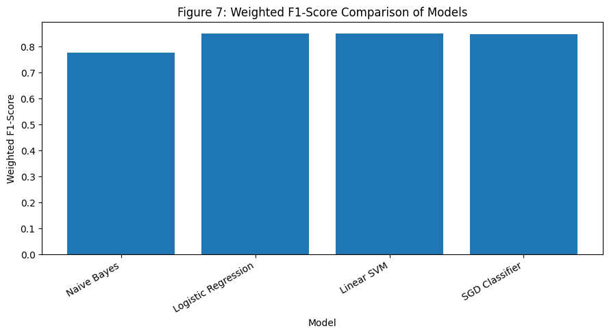

```python
# Create evaluation function
def evaluate_model(model_name, y_true, y_pred):
    return {
        "Model": model_name,
        "Accuracy": accuracy_score(y_true, y_pred),
        "Precision": precision_score(y_true, y_pred, average="weighted"),
        "Recall": recall_score(y_true, y_pred, average="weighted"),
        "F1_Score": f1_score(y_true, y_pred, average="weighted"),
        "Macro_F1": f1_score(y_true, y_pred, average="macro")
    }

# Store evaluation results
evaluation_results = [
    evaluate_model("Naive Bayes", y_test, nb_predictions),
    evaluate_model("Logistic Regression", y_test, lr_predictions),
    evaluate_model("Linear SVM", y_test, svm_predictions),
    evaluate_model("SGD Classifier", y_test, sgd_predictions)
]

# Convert results into dataframe
evaluation_df = pd.DataFrame(evaluation_results)

# Round results
evaluation_df_rounded = evaluation_df.copy()
numeric_columns = ["Accuracy", "Precision", "Recall", "F1_Score", "Macro_F1"]
evaluation_df_rounded[numeric_columns] = evaluation_df_rounded[numeric_columns].round(4)

print("Model Evaluation Results:")
display(evaluation_df_rounded)

# Plot model F1-score comparison
plt.figure(figsize=(9, 5))
plt.bar(evaluation_df_rounded["Model"], evaluation_df_rounded["F1_Score"])

plt.title("Figure 7: Weighted F1-Score Comparison of Models")
plt.xlabel("Model")
plt.ylabel("Weighted F1-Score")
plt.xticks(rotation=30, ha="right")
plt.tight_layout()
plt.show()
```

## 24. Model Evaluation

The accuracy, precision, recall, weighted F1-Score, and macro F1-Score were used to assess all trained models. Logistic Regression overall gave the highest accuracy (0.8521) and weighted F1 score (0.8524).

Linear SVM had very close performance to Logistic Regression (LR) with weighted F1 = 0.8501. SGD Classifier also performed well but the poorest performance was for Naive Bayes.

```
Model comparison ranked by weighted F1-score:
```

|  | Model | Accuracy | Precision | Recall | F1_Score | Macro_F1 |
| --- | --- | --- | --- | --- | --- | --- |
| 0 | Logistic Regression | 0.8521 | 0.8556 | 0.8521 | 0.8524 | 0.8516 |
| 1 | Linear SVM | 0.8502 | 0.8505 | 0.8502 | 0.8501 | 0.8502 |
| 2 | SGD Classifier | 0.8488 | 0.8523 | 0.8488 | 0.8486 | 0.8462 |
| 3 | Naive Bayes | 0.7821 | 0.8057 | 0.7821 | 0.7785 | 0.7515 |

```
Best Model: Logistic Regression
Best Accuracy: 0.8521
Best Weighted F1-Score: 0.8524
```

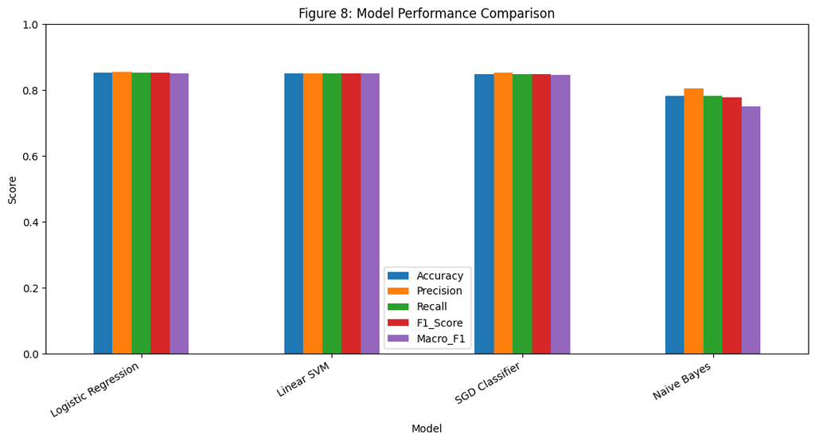

```python
# Sort models by weighted F1-score
model_comparison = evaluation_df_rounded.sort_values(
    by="F1_Score",
    ascending=False
).reset_index(drop=True)

print("Model comparison ranked by weighted F1-score:")
display(model_comparison)

# Select best model
best_model_name = model_comparison.loc[0, "Model"]
best_f1_score = model_comparison.loc[0, "F1_Score"]
best_accuracy = model_comparison.loc[0, "Accuracy"]

print("\nBest Model:", best_model_name)
print("Best Accuracy:", best_accuracy)
print("Best Weighted F1-Score:", best_f1_score)

# Plot comparison of all metrics
metrics = ["Accuracy", "Precision", "Recall", "F1_Score", "Macro_F1"]

model_comparison.set_index("Model")[metrics].plot(kind="bar", figsize=(11, 6))

plt.title("Figure 8: Model Performance Comparison")
plt.xlabel("Model")
plt.ylabel("Score")
plt.xticks(rotation=30, ha="right")
plt.ylim(0, 1)
plt.tight_layout()
plt.show()
```

```
Confusion Matrix for Logistic Regression:
```

|  | Access | Administrative rights | HR Support | Hardware | Internal Project | Miscellaneous | Purchase | Storage |
| --- | --- | --- | --- | --- | --- | --- | --- | --- |
| Access | 1266 | 14 | 24 | 54 | 16 | 37 | 3 | 11 |
| Administrative rights | 5 | 300 | 5 | 35 | 1 | 5 | 0 | 1 |
| HR Support | 39 | 17 | 1838 | 140 | 32 | 87 | 5 | 25 |
| Hardware | 63 | 100 | 141 | 2175 | 37 | 128 | 33 | 46 |
| Internal Project | 2 | 0 | 8 | 11 | 399 | 4 | 0 | 0 |
| Miscellaneous | 24 | 8 | 43 | 77 | 19 | 1212 | 3 | 26 |
| Purchase | 2 | 3 | 5 | 23 | 1 | 9 | 447 | 3 |
| Storage | 1 | 3 | 7 | 18 | 1 | 10 | 0 | 515 |

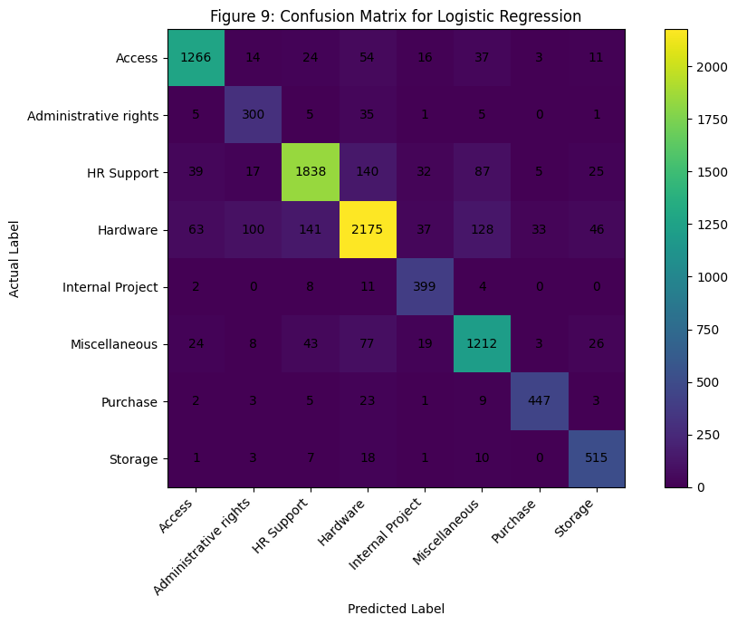

```
Classification Report for Best Model:
                       precision    recall  f1-score   support

               Access       0.90      0.89      0.90      1425
Administrative rights       0.67      0.85      0.75       352
           HR Support       0.89      0.84      0.86      2183
             Hardware       0.86      0.80      0.83      2723
     Internal Project       0.79      0.94      0.86       424
        Miscellaneous       0.81      0.86      0.83      1412
             Purchase       0.91      0.91      0.91       493
              Storage       0.82      0.93      0.87       555

             accuracy                           0.85      9567
            macro avg       0.83      0.88      0.85      9567
         weighted avg       0.86      0.85      0.85      9567
```

```python
# Use Logistic Regression as the best model
best_predictions = lr_predictions

# Create confusion matrix
cm = confusion_matrix(y_test, best_predictions)

# Convert confusion matrix into dataframe
cm_df = pd.DataFrame(
    cm,
    index=label_encoder.classes_,
    columns=label_encoder.classes_
)

print("Confusion Matrix for Logistic Regression:")
display(cm_df)

# Plot confusion matrix
plt.figure(figsize=(10, 7))
plt.imshow(cm, interpolation="nearest")
plt.title("Figure 9: Confusion Matrix for Logistic Regression")
plt.xlabel("Predicted Label")
plt.ylabel("Actual Label")
plt.colorbar()

tick_marks = np.arange(len(label_encoder.classes_))
plt.xticks(tick_marks, label_encoder.classes_, rotation=45, ha="right")
plt.yticks(tick_marks, label_encoder.classes_)

# Add values inside cells
for i in range(cm.shape[0]):
    for j in range(cm.shape[1]):
        plt.text(
            j,
            i,
            cm[i, j],
            ha="center",
            va="center"
        )

plt.tight_layout()
plt.show()

# Show classification report again for best model
print("\nClassification Report for Best Model:")
print(classification_report(
    y_test,
    best_predictions,
    target_names=label_encoder.classes_
))
```

## 25. Confusion Matrix Analysis

- The confusion matrix was generated for the best of all models, which was Logistic Regression. The model was able to correctly classify many records for each category. The performances were good for the areas of `Access`, `HR Support, Hardware`, `Internal Project, Purchase` and `Storage`.
- The rest of the categories were not as good; the F1-scores were below 0.9 for all other categories.The best category performance was for Purchase with an F1-score of 0.91 and Access was not far behind with an F1-score of 0.90. The F1-Score for this category, namely `Administrative rights`, is the lowest at 0.75.
- There was some mixup in the levels of the similar events. An example of this is when some `Hardware` tickets were forecast as `HR support`, `Administrative rights`, or `Miscellaneous`. This may happen because the words are similar in multiple categories for ticket text.

```python
# Custom unseen ticket examples
custom_tickets = [
    "I cannot access the finance shared folder and need permission urgently.",
    "My laptop keyboard is not working and the screen is flickering.",
    "Please approve the purchase of a new monitor and wireless mouse.",
    "I need administrative rights to install Python software on my system.",
    "My mailbox storage is full and I cannot receive new emails.",
    "A new employee has joined and needs HR onboarding support.",
    "Please create a new pipeline for the internal project deployment.",
    "The application shows an error when I try to open the report."
]

# Clean and preprocess custom tickets
custom_tickets_cleaned = [preprocess_text(clean_ticket_text(ticket)) for ticket in custom_tickets]

# Transform custom tickets using trained TF-IDF vectorizer
custom_tickets_tfidf = tfidf_vectorizer.transform(custom_tickets_cleaned)

# Predict using best model: Logistic Regression
custom_predictions = lr_model.predict(custom_tickets_tfidf)

# Convert encoded predictions back to category names
custom_predicted_labels = label_encoder.inverse_transform(custom_predictions)

# Create result dataframe
custom_results = pd.DataFrame({
    "Original_Ticket": custom_tickets,
    "Cleaned_Ticket": custom_tickets_cleaned,
    "Predicted_Category": custom_predicted_labels
})

print("Custom Ticket Prediction Results:")
display(custom_results)
```

```
Custom Ticket Prediction Results:
```

|  | Original_Ticket | Cleaned_Ticket | Predicted_Category |
| --- | --- | --- | --- |
| 0 | I cannot access the finance shared folder and ... | cannot access finance shared folder need permi... | Storage |
| 1 | My laptop keyboard is not working and the scre... | laptop keyboard working screen flickering | Hardware |
| 2 | Please approve the purchase of a new monitor a... | please approve purchase new monitor wireless m... | Purchase |
| 3 | I need administrative rights to install Python... | need administrative right install python softw... | Administrative rights |
| 4 | My mailbox storage is full and I cannot receiv... | mailbox storage full cannot receive new email | Storage |
| 5 | A new employee has joined and needs HR onboard... | new employee joined need onboarding support | Hardware |
| 6 | Please create a new pipeline for the internal ... | please create new pipeline internal project de... | Internal Project |
| 7 | The application shows an error when I try to o... | application show error try open report | HR Support |

```python
# Save the best model, TF-IDF vectorizer, and label encoder
joblib.dump(lr_model, "final_logistic_regression_model.pkl")
joblib.dump(tfidf_vectorizer, "tfidf_vectorizer.pkl")
joblib.dump(label_encoder, "label_encoder.pkl")

print("Final pipeline components saved successfully:")
print("1. final_logistic_regression_model.pkl")
print("2. tfidf_vectorizer.pkl")
print("3. label_encoder.pkl")

# Define final prediction function
def predict_ticket_category(ticket_text):
    cleaned_text = clean_ticket_text(ticket_text)
    preprocessed_text = preprocess_text(cleaned_text)
    vectorized_text = tfidf_vectorizer.transform([preprocessed_text])
    prediction = lr_model.predict(vectorized_text)
    predicted_category = label_encoder.inverse_transform(prediction)
    return predicted_category[0]

# Test final prediction function
test_ticket = "I need admin rights to install software on my laptop."
predicted_result = predict_ticket_category(test_ticket)

print("\nTest Ticket:")
print(test_ticket)

print("\nPredicted Category:")
print(predicted_result)
```

```
Final pipeline components saved successfully:
1. final_logistic_regression_model.pkl
2. tfidf_vectorizer.pkl
3. label_encoder.pkl

Test Ticket:
I need admin rights to install software on my laptop.

Predicted Category:
Administrative rights
```

## 26. Final System Design Explanation

- The final NLP system is meant to be able to automatically classify IT service tickets based on the trained Logistic Regression model. If a new ticket is added as raw text, the system first cleans the text, which is then completed in lowercase and unnecessary items like unnecessary spaces, special characters, URLs and email addresses are deleted at this point. Prepares the text of the ticket to be processed by NLP.
- Following the cleaning process, the text in the ticket is preprocessed by stopping frequent and unimportant words and removing very short words before performing lemmatization. These steps help to minimise noise, and preserve the important words within the ticket. The preprocessed text is then fed to the saved TF-IDF vectorizer to transform it into numerical features.
- These TF-IDF features are used by the trained Logistic Regression model to predict the correct classification of the ticket. This numeric label is mapped back to its corresponding label category name using the previously saved label encoder. The final answer that we'll get is the topic group that we predict, for example, Hardware, Access, HR Support, Storage, Purchase, Internal Project, Miscellaneous, or Administrative rights.

## 27. Results Discussion

As per the results, the NLP pipeline was able to classify the IT service tickets into 8 topic groups. Four machine learning models, namely Naive Bayes, Logistic Regression, Linear SVM and SGD Classifier, have been trained and tested. Logistic Regression model performed best with accuracy of 0.8521 and weighted F1 value of 0.8524 among the models.

The model worked well in areas like Access, Purchase, Storage, HR Support and Internal Project. Purchase had the best available F1-score (0.91), indicating that there are clear and helpful keywords present in purchase related tickets. The F1 was also decent for Access (0.90).

The category with the lowest score was Administrative rights with F1 score of 0.75. This may be because administrative rights tickets are using similar words to access, hardware and software installation issues. There was also some overlap in categories, such as between Hardware and HR Support and Miscellaneous.

Overall, the results are suitable for a business support environment. The model can help route many tickets automatically, but unclear or low-confidence tickets should still be reviewed by a human support agent.

## 28. Strengths of the Proposed Pipeline

The proposed NLP pipeline makes several points. First, it follows an end-to-end process and makes it more clear and practical. Second, the data is also well suited to supervised NLP since there are ticket text and categories that are to be classified.

The use of TF-IDF leads to easy understanding of the text and the application of classical machine learning models. Logistic Regression had the best results with accuracy 0.8521 and weighted F1 score 0.8524.

The system is also user-friendly and quick to operate. It can be used to classify the text of new tickets and give a predicted category. It's helpful for routing tickets at the first level in an IT service desk ticketing system.

## 29. Limitations of the Proposed Pipeline

Some of the drawbacks to the proposed NLP pipeline include: Only two columns left in the dataset, therefore only the text of the ticket and the labels of its category are used into the model. Does not contain information for a business like ticket priority, resolution time, user department, ticket status, or assigned support team.

There are several overlaps between the categories. For instance, Access and Administrative rights might have similar access, login and software installation related terms. There can also be mixed issues in the miscellaneous tickets making classification difficult.

This model is effective for most tickets, but may be incorrect for very short or ambiguous ticket text or in unusual cases. If a business is going to use the prediction, then it should be confirmed by a human support agent.

## 30. Business Recommendations

In an IT service desk an initial-level ticket routing system can be created using the final Logistic Regression model. If a new ticket is submitted, it can be predicted which of the support topics the corresponding group belongs to, and automatically forwarded to the correct support category.

The company must look to using the model to minimize manual sorting of tickets and to help decrease response time. The model was performing well on these classes, and they can be automatically rerouted to other categories like Access, Purchase, Storage, HR Support, and Internal Project.

Tickets that contain unclear text or have low prediction confidence should be sent to get manually reviewed. This is key in categories like Administrative rights or Miscellaneous, where it might be possible to get mixed up.

It is also important to note that the company has to retrain the model on fresh data on tickets periodically. Additional fields like ticket priority, resolution time, department and ticket status can be added to future versions of the system to enhance the business value and prediction accuracy.

## 31. Conclusion

This project created an entire NLP pipeline for automatic classification of IT service tickets. It used the Topic_group column as the target category and the Document column was used as the ticket text. Text data was cleaned and preprocessed and then transformed into TF-IDF features to train four machine learning models.

Logistic Regression had the highest accuracy score of 0.8521 and weighted F1-score of 0.8524. Results indicate that the model is effective at correctly categorizing numerous IT tickets and assisting with quicker ticket routing.

The system can reduce the workload of manual work, shorten response time and be able to effectively handle service desk tickets. There are various enhancements that can be added in the future, such as adding additional information on the ticket like confidence scores, and more advanced models like BERT.

# Reference list

Dlodlo, D. and Sibanda, K. (2023). Automated Ticket Classification for Information Technology Helpdesks using Machine Learning. 2023 2nd Zimbabwe Conference of Information and Communication Technologies (ZCICT), [online] pp.1–7. doi:https://doi.org/10.1109/zcict59466.2023.10528578.

Feng, L., Senapati, J. and Liu, B. (2023). TaDaa: real time Ticket Assignment Deep learning Auto Advisor for customer support, help desk, and issue ticketing systems. [online] arXiv.org. doi:https://doi.org/10.48550/arXiv.2207.11187.

Khowongprasoed, K. and Titijaroonroj, T. (2022). Automatic Thai Ticket Classification By Using Machine Learning For IT Infrastructure Company. [online] doi:https://doi.org/10.1109/jcsse54890.2022.9836250.

Pereira, L.S.B., Pizzio, R., Bonho, S., De Souza, L.M.F. and Junior, A.C.A. (2023). Machine Learning for Classification of IT Support Tickets. [online] IEEE Xplore. doi:https://doi.org/10.1109/CyMaEn57228.2023.10051041.

Pidej, C. and Thaicharoen, S. (2021). Bilingual IT Service Desk Ticket Classification Using Language Model Pre-training Techniques. 2021 16th International Joint Symposium on Artificial Intelligence and Natural Language Processing (iSAI-NLP), [online] pp.1–6. doi:https://doi.org/10.1109/iSAI-NLP54397.2021.9678179.

Truss, M. and Böhm, S. (2024). AI-based Classification of Customer Support Tickets: State of the Art and Implementation with AutoML. [online] ResearchGate. Available at: https://www.researchgate.net/publication/380365325_AI-based_Classification_of_Customer_Support_Tickets_State_of_the_Art_and_Implementation_with_AutoML [Accessed 20 Jun. 2026].

Yulio Ferdinand, Lubis, M. and Pratiwi, O.N. (2025). Classification of University IT Helpdesk Tickets Using Support Vector Machine with Hyperparameter Optimization. Jurnal Sisfokom (Sistem Informasi dan Komputer), [online] 14(4), pp.517–524. doi:https://doi.org/10.32736/sisfokom.v14i4.2413.

Zicari, P., Folino, G., Guarascio, M. and Pontieri, L. (2022). Combining deep ensemble learning and explanation for intelligent ticket management. Expert Systems with Applications, [online] 206, p.117815. doi:https://doi.org/10.1016/j.eswa.2022.117815.

# Appendix

Dataset Link: https://www.kaggle.com/datasets/adisongoh/it-service-ticket-classification-dataset

GitHub Link: https://github.com/harjot37/it-ticket-classification-nlp